# Classification

```r
data_path <- "Classification.csv"
cols <- c("Disability program", "Water resourses project", "Adoption project",  "Law on helthcare", "Salvador project", "Law on religions",
          "Antisatellite project",  "Nicaragua assistance project", "Rocket project",   "Law on immigrants",    "Alternative fuel sources", "Law on education",
          "Project on funds",   "Project on crime", "Project of customs",   "Project exports",  "Class")
senators <- read.csv(data_path, sep = '\t', header = FALSE, col.names = cols)
```

Split democrats and republicans:

```r
republicans <- senators[senators$Class == "republican",]
democrats <- senators[senators$Class == "democrat",]
```

Democrats outnumber republicans:

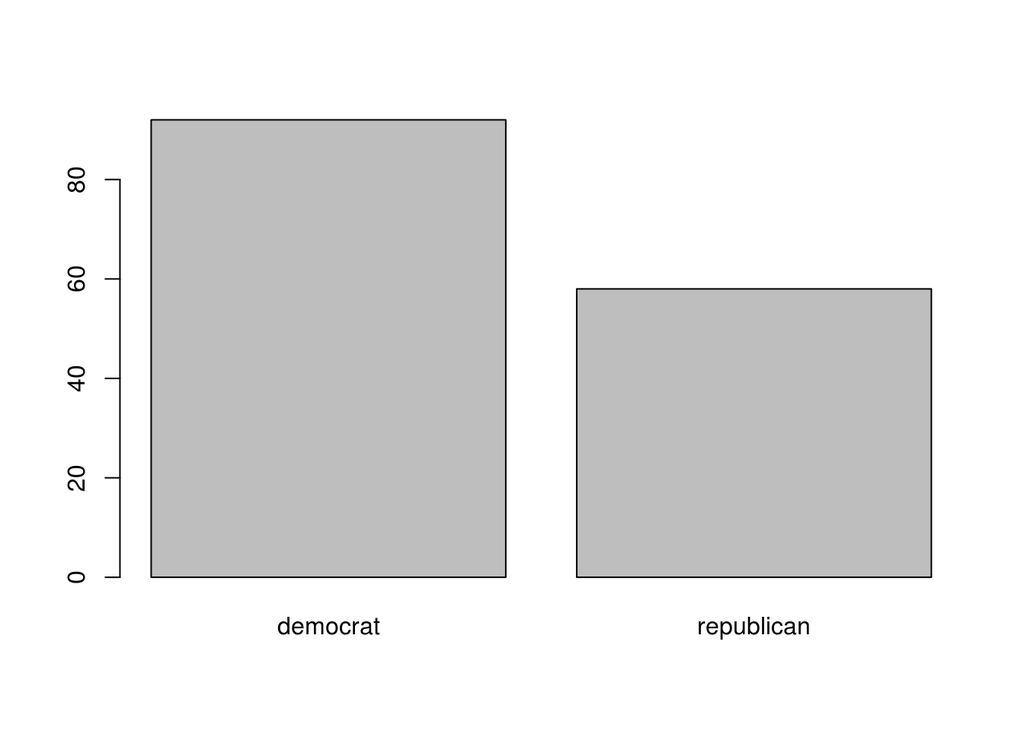

```r
barplot(table(senators$Class), col="grey")
```

There are more supporters for Law on religion than opponents

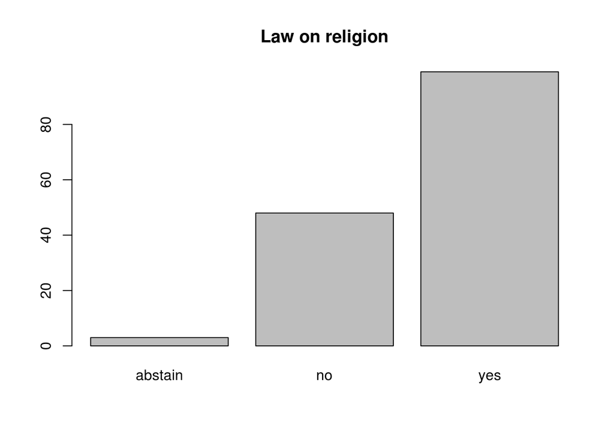

```r
barplot(table(senators$Law.on.religions), col="grey", main = "Law on religion")
```

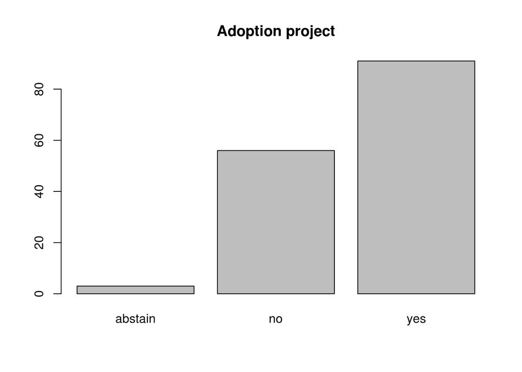

```r
barplot(table(senators$Adoption.project), col="grey", main = "Adoption project")
```

```r
require(corrgram)
```

```r
plotCorrelation <- function (data){

  data <- subset(data, select = -c(Class))

  data.reval <-  apply(data, 2, function(column){
    column <- as.numeric(factor(column, levels=c("no", "abstain", "yes")))
  })

  corrgram(data.reval, order = FALSE, cor.method = "kendall")
  #corrgram(cor.senator.reval, order = FALSE, cor.method = "kendall", lower.panel=panel.ellipse, upper.panel=panel.pie, text.panel=panel.txt)
}
```

We canHigh positive correlation between Nicaragua assistance and Adoption project. People who vote for them also voted for Rocket and Antisetellite projects. Another possible cluster may be formed by supporters for Law on healcare, Salvador project and Law on religion. This cluster is related to another possible group formed by supporters of Law on education, Project on funds and Project on crime.

Two possible groups formed.

[figure not shown]

```r
plotCorrelation(senators)
```

Nicaragua and Rocket projects are mostly supported by democrats

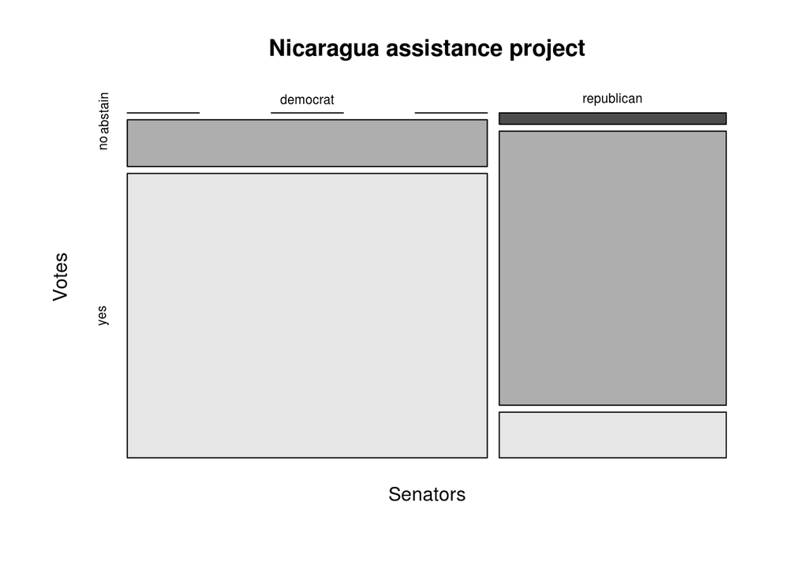

```r
mosaicplot(senators$Class ~ senators$Nicaragua.assistance.project, shade=FALSE, color=TRUE, main="Nicaragua assistance project", xlab = "Senators", ylab ="Votes")
```

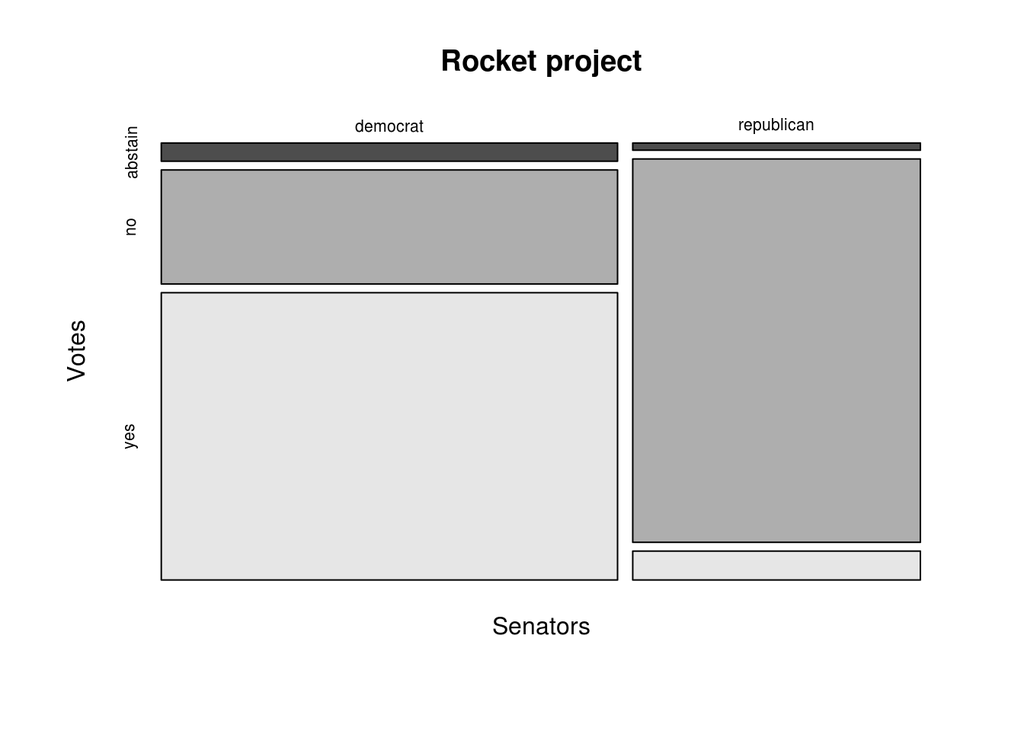

```r
mosaicplot(senators$Class ~ senators$Rocket.project, shade=FALSE, color=TRUE, main="Rocket project", xlab = "Senators", ylab ="Votes")
```

Salvador and Funds mostly by republicans

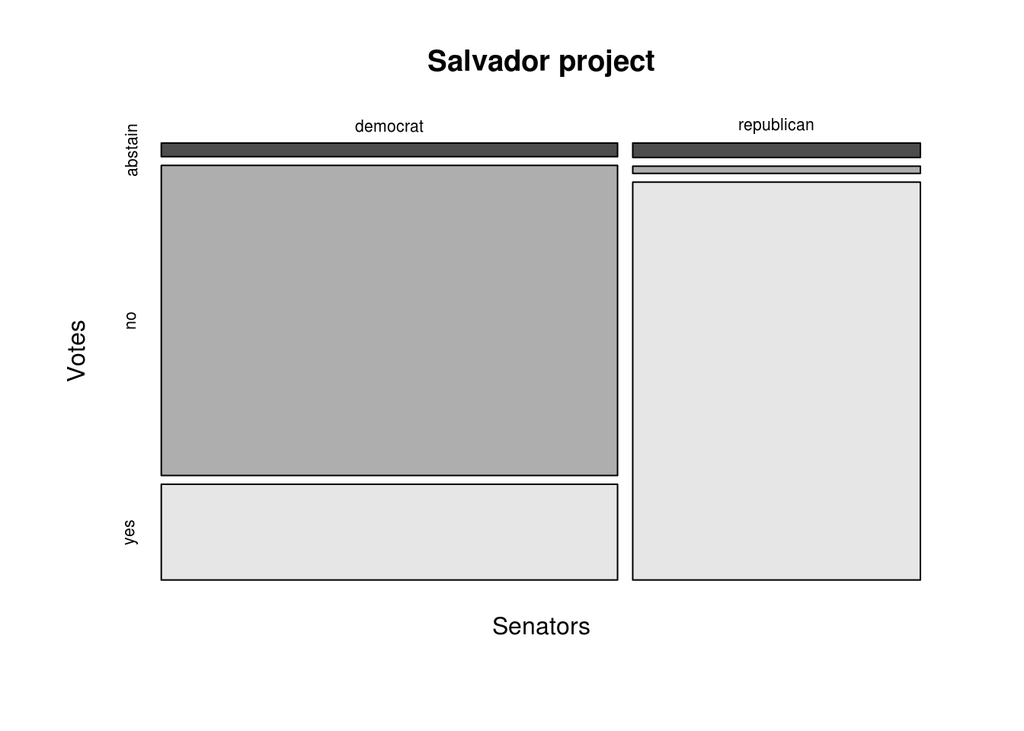

```r
mosaicplot(senators$Class ~ senators$Salvador.project, shade=FALSE, color=TRUE, main="Salvador project", xlab = "Senators", ylab ="Votes")
```

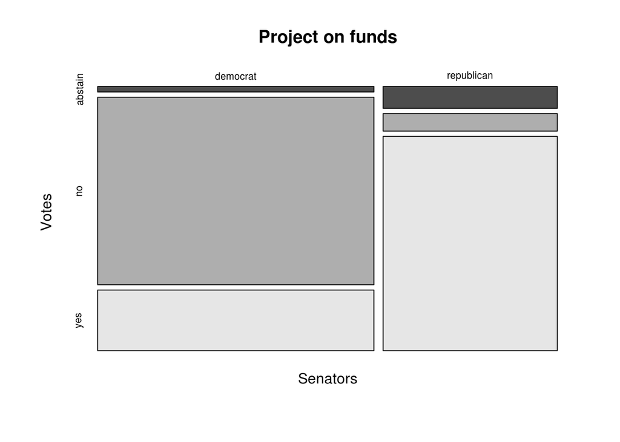

```r
mosaicplot(senators$Class ~ senators$Project.on.funds, shade=FALSE, color=TRUE, main="Project on funds", xlab = "Senators", ylab ="Votes")
```

Inside republicans two possible clusters can be seen: #1 Antisettellite proj, Nicaragua proj and Adoption project supporters #2 Law on healhcare, Salvador, Law on religion

[figure not shown]

```r
plotCorrelation(republicans)
```

Democrats are more separeted. Supporters for Salvador/Law on religion have different opition with supporters Rocket and Nicaragua projects. There is no one opition for those problems inside democrats. They look more separable than republicans

[figure not shown]

```r
plotCorrelation(democrats)
```

```r
#add heat map for Salvador vs Rocket projects http://www.r-bloggers.com/search/heatmap
```

```r
clust.hierarchically <- function(data){
  library(cluster)
  library(stats)

  data.dist <- daisy(data, metric = "gower", stand = TRUE)
  data.hc <- hclust(data.dist, method="complete")
  return(data.hc)
}
get.groups <- function(data, groups.num){
  library(stats)
  data.hc <- clust.hierarchically(data)
  groups <- cutree(data.hc, groups.num)
  return(cbind(data, groups))
}
```

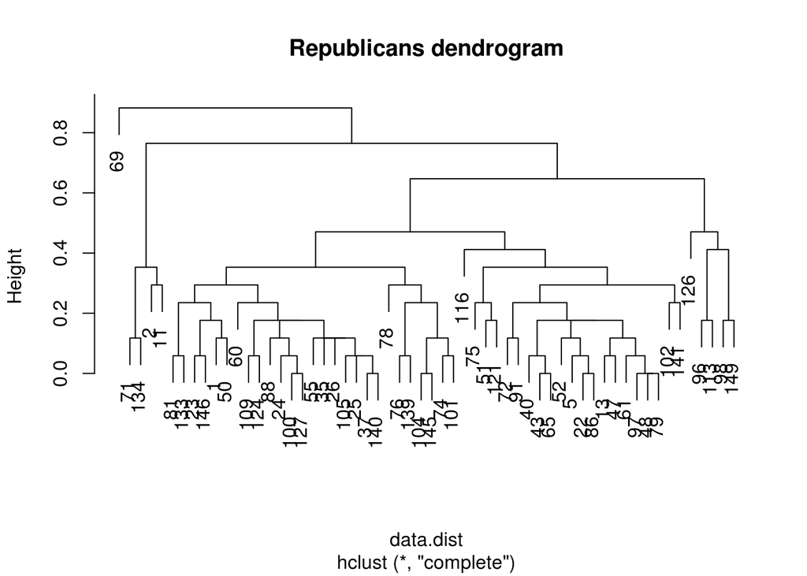

```r
republicans.hc <- clust.hierarchically(republicans)
plot(republicans.hc, main = "Republicans dendrogram")
```

There is one senator #69 with totally different opinion. Event distant senators #71 and #149 vote for Antisatellite, Nicaragua, Salvador projects together.

```r
senators[c(69, 71, 149),]
```

```
##     Disability.program Water.resourses.project Adoption.project
## 69                  no                 abstain          abstain
## 71                  no                      no              yes
## 149                yes                     yes              yes
##     Law.on.helthcare Salvador.project Law.on.religions
## 69           abstain          abstain          abstain
## 71               yes              yes              yes
## 149              yes              yes              yes
##     Antisatellite.project Nicaragua.assistance.project Rocket.project
## 69                abstain                      abstain        abstain
## 71                    yes                          yes            yes
## 149                   yes                          yes             no
##     Law.on.immigrants Alternative.fuel.sources Law.on.education
## 69            abstain                  abstain          abstain
## 71                yes                       no              yes
## 149               yes                  abstain          abstain
##     Project.on.funds Project.on.crime Project.of.customs Project.exports
## 69           abstain              yes            abstain         abstain
## 71               yes              yes                yes             yes
## 149          abstain              yes                 no             yes
##          Class
## 69  republican
## 71  republican
## 149 republican
```

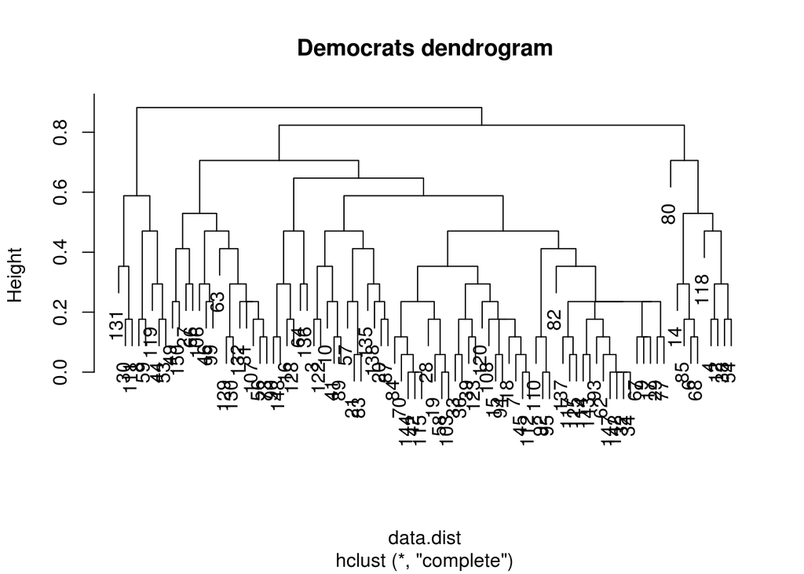

```r
democrats.hc <- clust.hierarchically(democrats)
plot(democrats.hc, main = "Democrats dendrogram")
```

```r
senators[c(28, 54, 131),]
```

```
##     Disability.program Water.resourses.project Adoption.project
## 28                 yes                     yes              yes
## 54                  no                     yes              yes
## 131                 no                     yes              yes
##     Law.on.helthcare Salvador.project Law.on.religions
## 28                no               no               no
## 54                no              yes              yes
## 131          abstain              yes              yes
##     Antisatellite.project Nicaragua.assistance.project Rocket.project
## 28                    yes                          yes            yes
## 54                     no                           no             no
## 131                    no                          yes             no
##     Law.on.immigrants Alternative.fuel.sources Law.on.education
## 28                 no                      yes               no
## 54                 no                      yes               no
## 131               yes                  abstain               no
##     Project.on.funds Project.on.crime Project.of.customs Project.exports
## 28                no               no                 no         abstain
## 54                no               no                yes         abstain
## 131              yes              yes            abstain             yes
##        Class
## 28  democrat
## 54  democrat
## 131 democrat
```

Group of republicans is very close to group of democrats

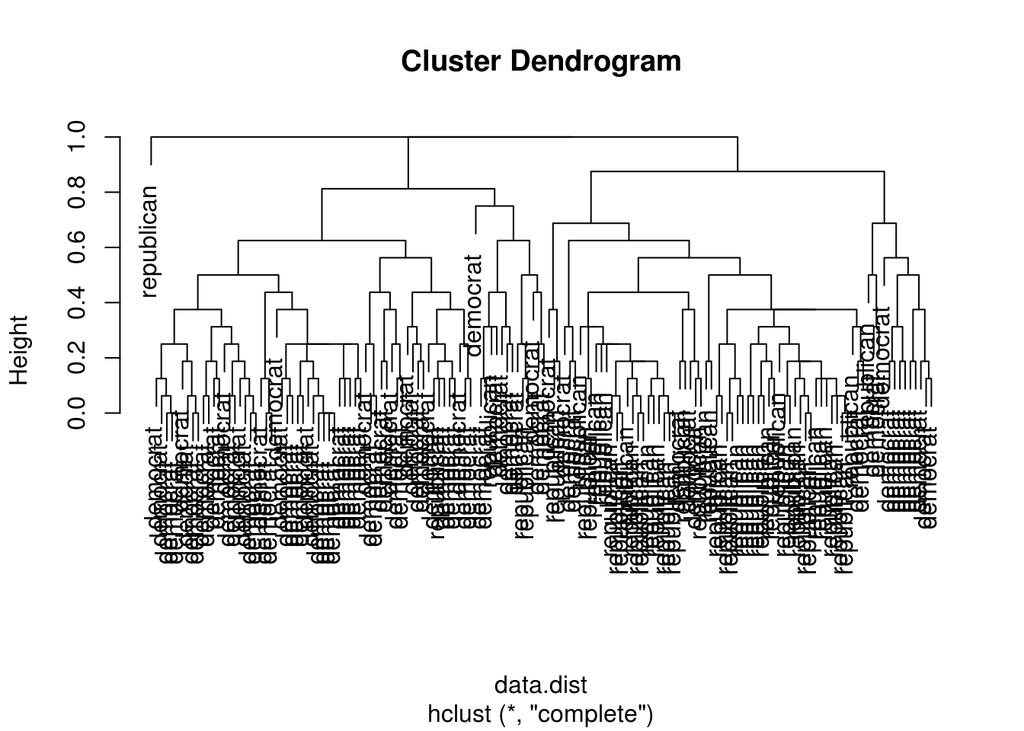

```r
senators.hc <- clust.hierarchically(subset(senators, select = -c(Class)))
senators.hc$labels <- senators$Class
#senators.hc$labels <- paste(as.character(senators.hc$order), as.character(senators$Class))
plot(senators.hc)
```

```r
get.number.of.clusters <- function(data) {
  library(fpc)
  library(cluster)

  data.dist <- daisy(data, metric = "gower", stand = TRUE)
  data.best <- pamk(data.dist)
  #cat("Number of clusters estimated by optimum average silhouette width:", data.best$nc, "\n")
  #visualized silhouette widthp
  #plot(pam(data.dist, data.best$nc))
  return(data.best)
}

clust.pam <- function(data, caption) {
  #par(mfrow=c(2,1))
  library(cluster)
  clust.num <- get.number.of.clusters(data)
  data.dist <- daisy(data, metric = "gower", stand = TRUE)
  pam.clust <- pam(data.dist, k=clust.num$nc)
  plot(pam(data.dist, clust.num$nc), main = paste("Silhouette plot for", caption))
  clusplot(pam.clust, main = paste("Partition around medoid for", caption)) #printed clusters
  return(pam.clust)
}
```

In general senators could be split in two groups

```r
senators.pam <- clust.pam(subset(senators, select = -c(Class)), 'senators')
```

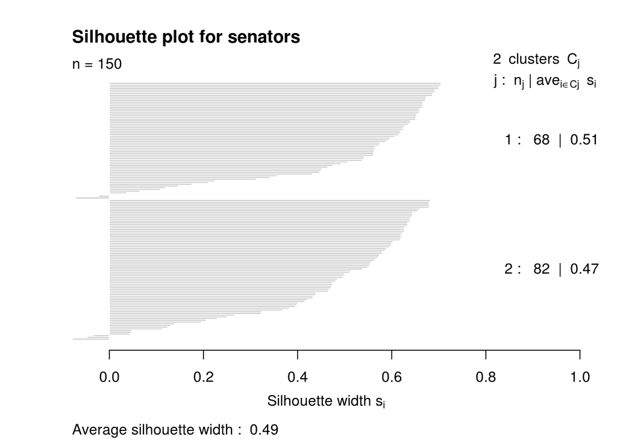

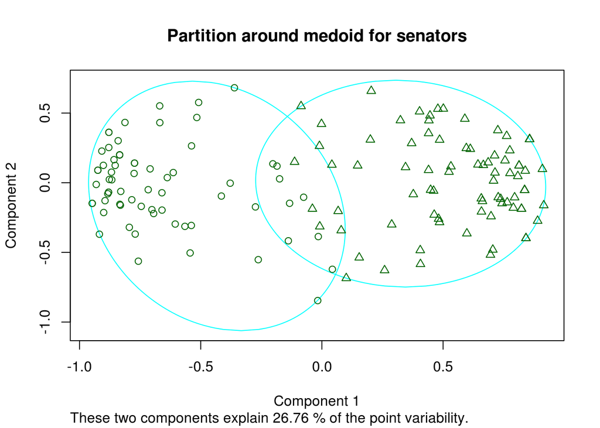

```r
republicans.pam <- clust.pam(republicans, 'republicans')
```

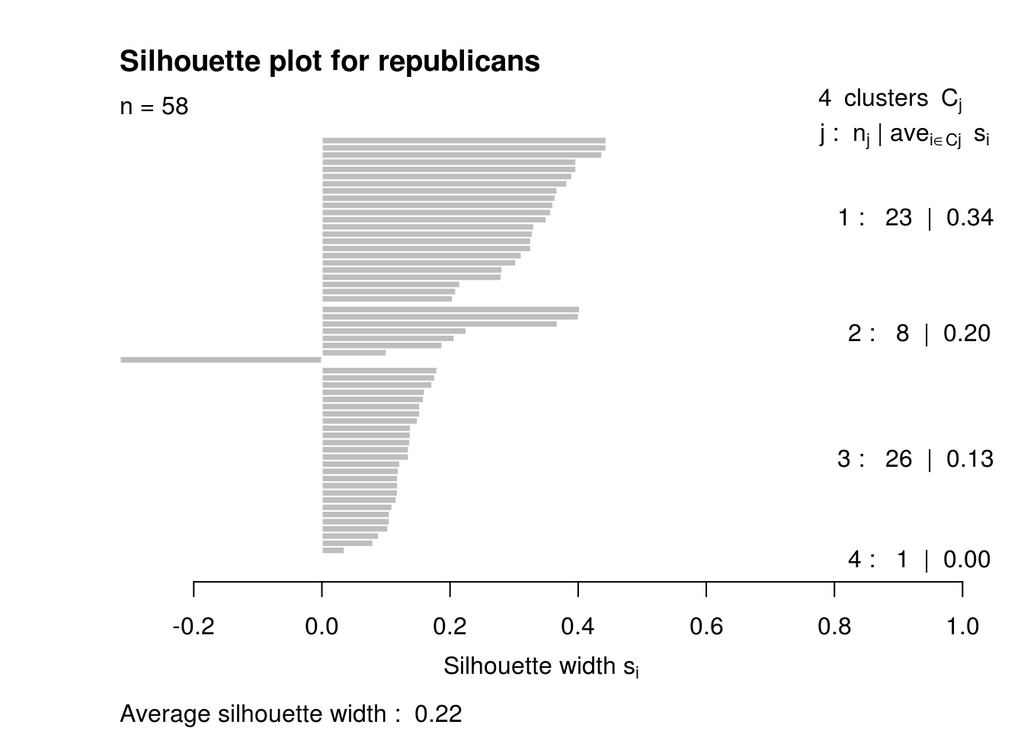

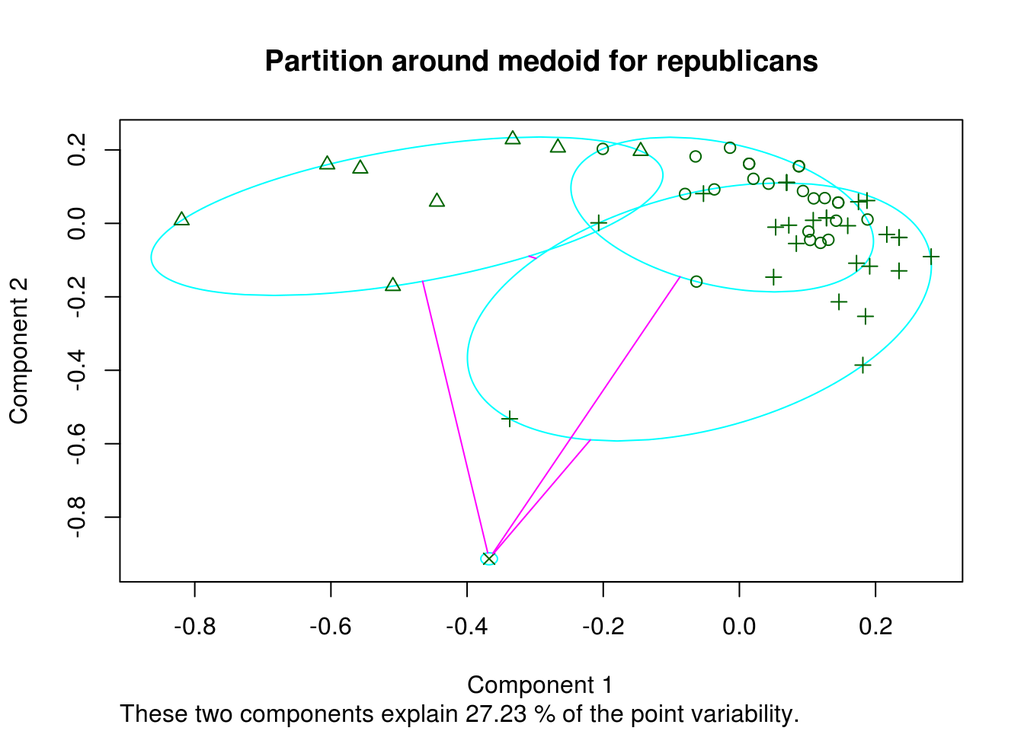

```r
democrats.pam <- clust.pam(democrats, 'democrats')
```

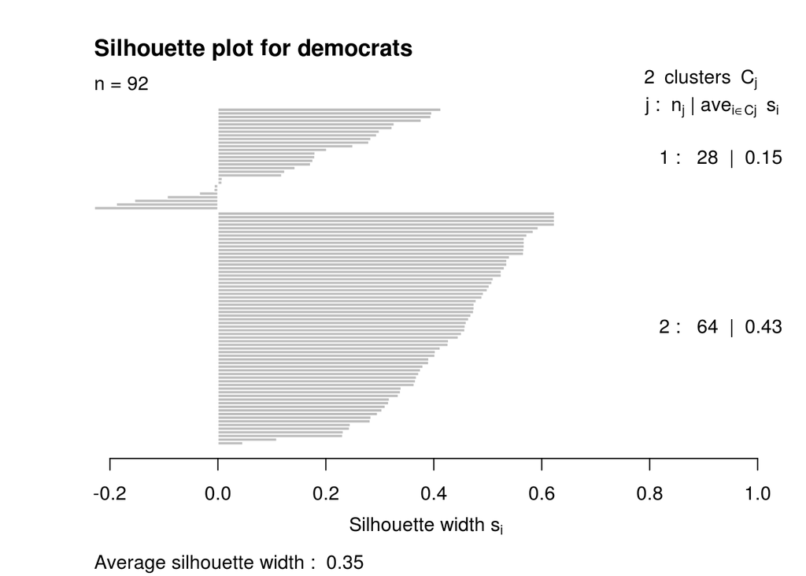

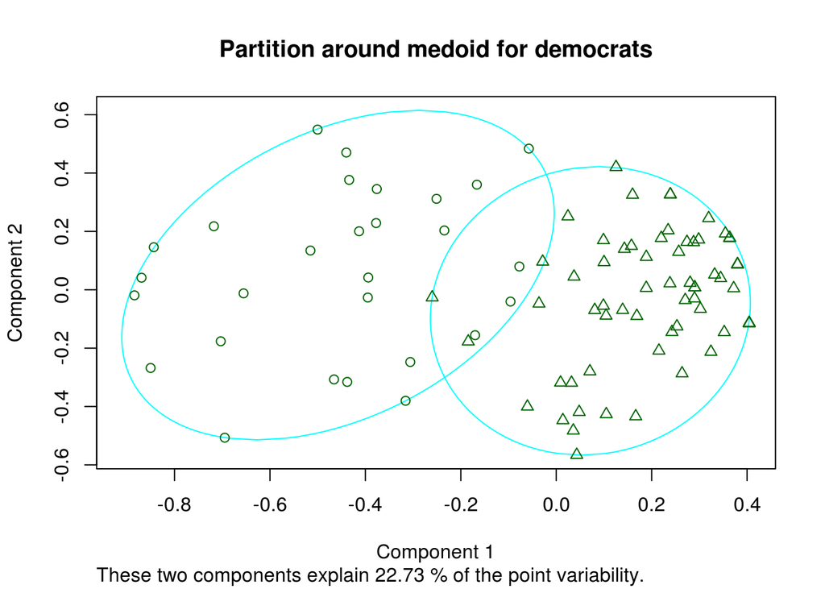